# Assignment 12

#### Subset

Subsetting the data after 1990

```r
subtemp <- subset(maxtemp, start=20) #Subsetting time series data from 1990 which is 20th index
```

Using SES predict next five years of maximum temperature of Melbourne. Plot forecast and predicted line overlay on the plot

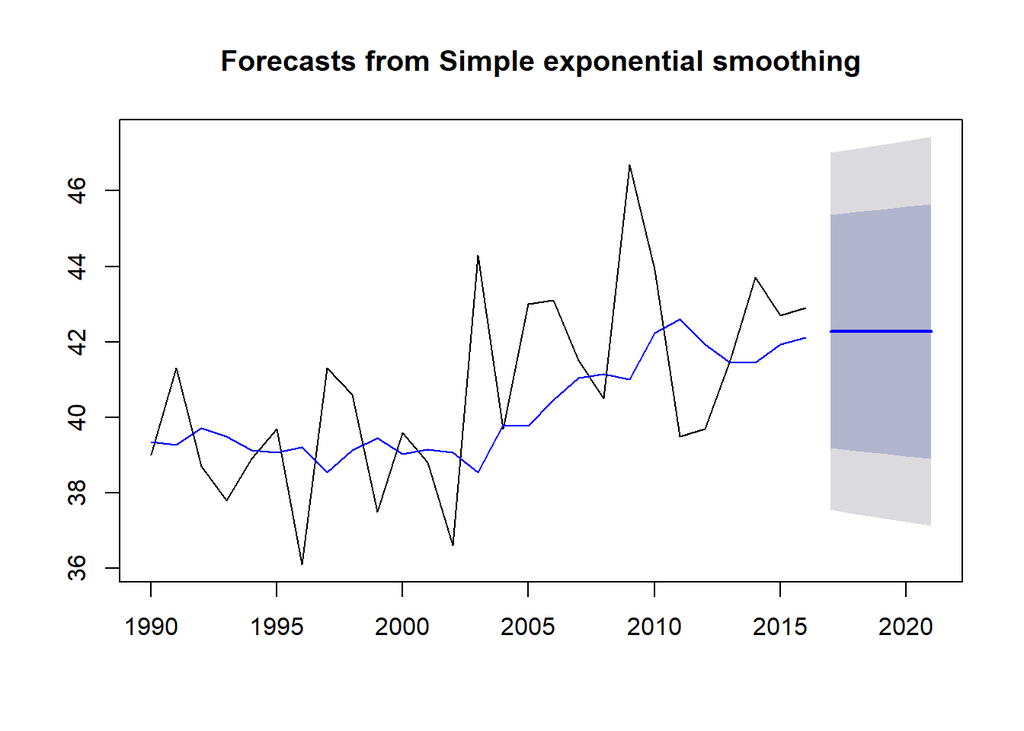

```r
fitsubtemp <- ses(subtemp, h=5) # Creating SES linear trend of the subset
plot(fitsubtemp) # Plot the fit
lines(fitted(fitsubtemp),col="blue") # Overlay the predicated line over plot
```

```r
summary(fitsubtemp) # Using summary collect AICs value
```

```
##
## Forecast method: Simple exponential smoothing
##
## Model Information:
## Simple exponential smoothing
##
## Call:
##  ses(y = subtemp, h = 5)
##
##   Smoothing parameters:
##     alpha = 0.2164
##
##   Initial states:
##     l = 39.345
##
##   sigma:  2.4135
##
##      AIC     AICc      BIC
## 140.4868 141.5302 144.3743
##
## Error measures:
##                     ME     RMSE      MAE      MPE     MAPE      MASE
## Training set 0.5018493 2.322345 1.776513 0.947593 4.301593 0.7390293
##                     ACF1
## Training set -0.09460844
##
## Forecasts:
##      Point Forecast    Lo 80    Hi 80    Lo 95    Hi 95
## 2017       42.27727 39.18431 45.37024 37.54700 47.00755
## 2018       42.27727 39.11272 45.44183 37.43750 47.11704
## 2019       42.27727 39.04271 45.51184 37.33043 47.22411
## 2020       42.27727 38.97418 45.58036 37.22563 47.32891
## 2021       42.27727 38.90705 45.64750 37.12296 47.43158
```

Using holt linear method predict next five years of maximum temperature of Melbourne. Plot forecast and predicted line overlay on the plot

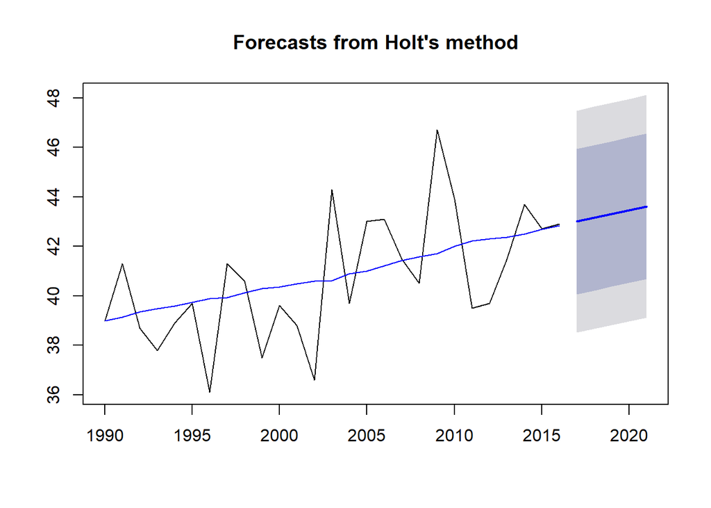

```r
fitholtsubtemp <- holt(subtemp, initial="optimal", h=5) # Creating holt linear tred of the subset
plot(fitholtsubtemp) # Plot the fit
lines(fitted(fitholtsubtemp),col="blue") # Overlay the predicated line over plot
```

```r
summary(fitholtsubtemp) # Using summary collect AICs value
```

```
##
## Forecast method: Holt's method
##
## Model Information:
## Holt's method
##
## Call:
##  holt(y = subtemp, h = 5, initial = "optimal")
##
##   Smoothing parameters:
##     alpha = 0.0306
##     beta  = 1e-04
##
##   Initial states:
##     l = 38.8273
##     b = 0.1545
##
##   sigma:  2.2891
##
##      AIC     AICc      BIC
## 139.3784 142.2355 145.8576
##
## Error measures:
##                      ME     RMSE      MAE        MPE     MAPE      MASE
## Training set -0.1742975 2.112723 1.642903 -0.7067033 4.055402 0.6834477
##                     ACF1
## Training set -0.05062112
##
## Forecasts:
##      Point Forecast    Lo 80    Hi 80    Lo 95    Hi 95
## 2017       42.99915 40.06558 45.93272 38.51264 47.48566
## 2018       43.15322 40.21827 46.08817 38.66460 47.64184
## 2019       43.30728 40.37095 46.24362 38.81654 47.79802
## 2020       43.46135 40.52362 46.39908 38.96848 47.95423
## 2021       43.61542 40.67628 46.55456 39.12039 48.11044
```

##### AICc for the different model are

1. SES –> 141.53

2. Holt –> 142.23

### 3. The Wands Choose the Wizard

#### Summary

Creating the timeseries of Wands from dataset provided and convert it to xts object and Using dygraph package analyse the timeseries

```r
df_gregowitch <- read.csv("source/Unit11TimeSeries_Gregorovitch.csv") #Creating dataset from Unit11TimeSeries_Gregorovitch.csv in source folder
df_ollivander <- read.csv("source/Unit11TimeSeries_Ollivander.csv") #Creating dataset from Unit11TimeSeries_Ollivander.csv in source folder
names(df_gregowitch) <- c("Year", "Numbers") #Name the column headers
names(df_ollivander) <- c("Year", "Numbers") #Name the column headers
df_gregowitch$Year <- as.Date.character(df_gregowitch$Year,format = "%d/%m/%Y") #Format the Year column proper date format
df_ollivander$Year <- as.Date.character(df_ollivander$Year,format = "%d/%m/%Y") #Format the Year column proper date format
xts_gregowitch <- as.xts(read.zoo(df_gregowitch)) #Convert data frame to xts object
xts_ollivander <- as.xts(read.zoo(df_ollivander)) #Convert data frame to xts object
merge_wands <-merge(xts_gregowitch,xts_ollivander) #Combine both the xts object
dygraph(merge_wands,main = "Wand sales comparison between wand makers", xlab = "Year", ylab = "Numbers") %>%   #Create dygraph
dySeries("xts_ollivander", label= "Olivander",drawPoints = TRUE,  color = "blue") %>%  dySeries("xts_gregowitch", label="Gregowitch", drawPoints = TRUE , color = "green") %>%  #Label and color the series
  dyRangeSelector() %>% #Activate range selector
dyShading(from = "1995-1-1", to = "1999-1-1", color = "orange") #Sharding the time between 1995-1999
```

[interactive chart not shown]

Git URL for this assignment is as follows https://github.com/ganeshkodi/smumsds_homework/tree/master/Homework12